# Cluster-RCT: Randomisierung und statistische Power

Studienplanung mit simulierten Versichertendaten

Autor:in

SK

# 1 Lernziele

In diesem Modul untersuchen wir, wie sich das **Design einer Cluster-randomisierten Studie** auf die statistische Power auswirkt.

Nach dem Modul kannst du:

1. Arztpraxen **innerhalb von Regionen randomisieren**;
2. korrelierte Hospitalisierungszahlen für Patienten derselben Praxis simulieren;
3. den Einfluss von **Praxiszahl, Praxisgröße und Intracluster-Korrelation (ICC)** untersuchen;
4. die Power eines Cluster-RCT durch wiederholte Simulation schätzen;
5. kontrollieren, ob ein Test unter der Nullhypothese ungefähr das vorgegebene Signifikanzniveau einhält.

**Bezug zum ersten Skript:** Dort analysieren wir ein bereits simuliertes Cluster-RCT mit 48 Praxen und etwa 2.000 Versicherten. Hier gehen wir einen Schritt zurück und untersuchen, **wie man ein solches Studiendesign vorab planen könnte**. Wir verwenden dafür neue, unabhängig simulierte Daten und benötigen keine CSV-Dateien.

> **Datenhinweis:** Sämtliche Praxen, Personen, Risiken und Ergebnisse werden künstlich erzeugt. Die gewählten Parameter sind Lehrannahmen, keine Ergebnisse einer realen klinischen Studie und keine belegten Effektgrößen für Telemonitoring.

# 2 Forschungsfrage und Studiendesign

## 2.1 Was wollen wir herausfinden?

**Forschungsfrage:** Wie viele Praxen und Patienten benötigen wir, um eine angenommene Verringerung der HF-Hospitalisierungsrate durch Telemonitoring mit ausreichender Wahrscheinlichkeit statistisch nachzuweisen? Mit anderen Worten: Wie beeinflussen die Anzahl randomisierter Arztpraxen, die Zahl der Patienten pro Praxis und die Intracluster-Korrelation die statistische Power einer cluster-randomisierten Studie?

Wir betrachten ein **stratifiziertes, parallelgruppiges Cluster-RCT**. Innerhalb jeder von vier Regionen werden gleich viele Praxen der Intervention oder der Regelversorgung zugeteilt. Alle Patienten einer Praxis erhalten dieselbe **randomisierte Zuteilung**.

| Bestandteil | Annahme in diesem Lehrprojekt |
| --- | --- |
| Randomisierungseinheit | Arztpraxis |
| Studienarme | Telemonitoring-Angebot und Regelversorgung |
| Regionen | Nord, Ost, Süd, West |
| Zielparameter | Incidence Rate Ratio (IRR) der HF-Aufnahmen |
| Angenommener Interventionseffekt | IRR = 0,80 (20 % niedrigere Rate) |
| Ausgangsrate | 0,8 HF-Aufnahmen pro Personenjahr, vor regionalen Unterschieden |
| Beobachtung | Eine Person wird ein volles Jahr beobachtet |
| Hauptanalyse | Poisson-Regression mit Region und cluster-robusten Standardfehlern |
| Test | Zweiseitig, Signifikanzniveau 5 % |

**Vereinfachungen:** Die Praxisgrößen sind innerhalb eines Szenarios gleich. Wir simulieren keine Todesfälle, fehlenden Werte, Nichtnutzung des Programms oder unterschiedliche Beobachtungszeiten. Der angenommene Effekt gilt daher direkt für die randomisierte Zuteilung.

## 2.2 Der Einfluss der Cluster-Abhängigkeit

Patienten derselben Praxis können sich ähnlicher sein als Patienten unterschiedlicher Praxen. Beispielsweise können regionale Besonderheiten, Behandlungsmuster und die Zusammensetzung der Patienten zu gemeinsamen Unterschieden zwischen den Praxen führen.

Die **ICC** beschreibt die Ähnlichkeit der Ergebnisse innerhalb eines Clusters. Wenn die ICC steigt, liefern zusätzliche Patienten derselben Praxis weniger *unabhängige* Information.

D.h. bei einer Cluster-Randomisierung sind die Beobachtungen innerhalb derselben Praxis korreliert. Dadurch enthalten 2.000 Patienten (einer Cluster-Randomisierung) weniger unabhängige statistische Information als bei einer individuellen Randomisierung. Der Design-Effekt beschreibt näherungsweise, um welchen Faktor sich die Varianz eines Schätzers aufgrund dieser Clusterabhängigkeit erhöht.

Wir nehmen beispielhaft 42 Patienten pro Praxis und eine Intracluster-Korrelation (ICC) von 0,05 an. Diese ICC ist ein frei gewählter Wert für unsere Simulation. In einer realen Studie müsste sie möglichst anhand früherer Studien oder Pilotdaten begründet werden.

Um zu veranschaulichen inwieweit sich die Varianz eines Schätzers durch Clusterabhängigkeit erhöht, berechnen wir den sogenannten **Design-Effekt** (für gleich große Cluster):

$$DE = 1 + (m-1)\cdot ICC$$

Dabei ist $m$ die Anzahl der Personen pro Praxis. Bei 42 Patienten und einer angenommenen ICC von 0,05 ergibt sich:

```r
patienten_pro_praxis <- 42
icc <- 0.05

design_effekt <- 1 + (patienten_pro_praxis - 1) * icc
round(design_effekt, 2)
```

```
[1] 3.05
```

**Interpretation**: Der Design-Effekt von 3,05 bedeutet, dass die Varianz unter den vereinfachenden Annahmen etwa 3,05-mal so groß ist wie bei unabhängigen Beobachtungen. Eine Stichprobe von 2.000 Patienten entspricht damit hinsichtlich der statistischen Information näherungsweise 656 unabhängigen Beobachtungen. Der tatsächliche Präzisionsverlust hängt allerdings vom konkreten Studiendesign und statistischen Analyseverfahren ab.

# 3 Settings

## 3.1 R-Pakete

Installiere die Pakete bei Bedarf einmalig in der R-Konsole:

```r
# install.packages(c("fixest", "ggplot2", "knitr", "modelsummary"))
```

```r
library(fixest)
library(ggplot2)
library(knitr)
library(modelsummary)
```

## 3.2 Simulationseinstellungen

```r
# Gleicher Startwert = reproduzierbare Zufallszahlen.
set.seed(2026)

# Für einen schnellen Test genügen 200 Wiederholungen.
# Für die abschließende Analyse besser 1.000 oder mehr wählen.
anzahl_wiederholungen <- 1000
```

**Hinweis:** Bei 200 Wiederholungen ist die geschätzte Power noch relativ ungenau. Wir erläutern diese Simulationsunsicherheit später. Die Berechnungszeit steigt mit der Zahl der Wiederholungen.

# 4 Praxen stratifiziert randomisieren

Zuerst schreiben wir eine einfache Funktion, die die Praxen gleichmäßig auf vier Regionen verteilt und **innerhalb jeder Region** jeweils die Hälfte den beiden Studienarmen (Interventionsgruppe und Kontrollgruppe) zufällig zuteilt.

Die Anzahl der Praxen muss hier durch acht teilbar sein: Es gibt vier Regionen mit jeweils zwei gleich großen Studienarmen.

```r
# Die Praxiszahl muss positiv und durch 8 teilbar sein.
# So erhalten alle vier Regionen gleich viele Praxen,
# die jeweils zur Hälfte auf Intervention und Kontrolle verteilt werden.
# Der Operator %% berechnet in R den Rest einer Division.
# Mit == 0 prüfen wir, ob die Anzahl der Praxen ohne Rest durch 8 teilbar ist.

randomisiere_praxen <- function(anzahl_praxen) {
  stopifnot(anzahl_praxen > 0, anzahl_praxen %% 8 == 0)

  praxen <- data.frame(
    praxis_id = 1:anzahl_praxen,     # Erzeugt eine fortlaufende Praxis IDs von 1-48
    region = factor(rep(c("Nord", "Ost", "Sued", "West"),
          each = anzahl_praxen / 4)),              # mit je (48/4=) 12 aus jeder Region
    intervention = 0L) # Alle Praxen sind vorläufig mit 0 (Kontrollgr) kodiert.

  # innerhalb jeder der vier Regionen werden genau die Hälfte der Praxen
  # zufällig der Interventionsgruppe und die andere Hälfte der Kontrollgruppe zugewiesen
  for (x in levels(praxen$region)) {
            zeilen <- which(praxen$region == x) # Zeilenlänge für jede Region=12
            haelfte <- length(zeilen) / 2     # 12/2 = 6
            # sample() mischt die Reihenfolge der beiden folgenden Vektoren zufällig
            # diese weden in die Spalte intervention der jeweiligen Praxen geschrieben
            praxen$intervention[zeilen] <- sample(c(
                    rep(0L, haelfte),    # 0 0 0 0 0 0
                    rep(1L, haelfte)))    # 1 1 1 1 1 1
  }

  return(praxen)
}
```

Wir probieren die Funktion mit **48 Praxen** aus und prüfen die Verteilung.

```r
praxen_beispiel <- randomisiere_praxen(48)

# erstelle im Beispiel-data.frame eine neue Faktor-Variable gruppe
praxen_beispiel$gruppe <- factor(
  praxen_beispiel$intervention,
  levels = c(0, 1),
  labels = c("Regelversorgung", "Telemonitoring")
)

# Häufigkeitstabelle: Praxen nach Region und Gruppe
knitr::kable(table(Region = praxen_beispiel$region, praxen_beispiel$gruppe),
    caption = "Zufällige Praxiszuteilung nach Region")
```

Zufällige Praxiszuteilung nach Region

|  | Regelversorgung | Telemonitoring |
| --- | --- | --- |
| Nord | 6 | 6 |
| Ost | 6 | 6 |
| Sued | 6 | 6 |
| West | 6 | 6 |

In jeder Region sollten **sechs Interventions- und sechs Kontrollpraxen** stehen. Welche *einzelnen* Praxen der Intervention zugeteilt werden, ist zufällig.

**Wichtig:** Randomisierung bedeutet nicht, dass alle Patientenmerkmale in den beiden Gruppen exakt gleich sind. Sie verhindert vielmehr, dass die Gruppenzuteilung systematisch von den späteren Ergebnissen abhängt.

# 5 Künstliche Studiendaten erzeugen

## 5.1 Gemeinsame Risikofaktoren innerhalb einer Praxis

Damit sich die Patienten einer Praxis ähneln, geben wir jeder Praxis einen zufälligen **Risikofaktor**. Dieser verändert die erwartete Zahl der Krankenhausaufnahmen für *alle* Patienten dieser Praxis.

Wir verwenden dafür eine Gamma-Verteilung. Somit sind die Risikofaktoren der Praxen positiv, haben einen Erwartungswert von 1 und variieren zwischen den Praxen. Zusammen mit der Poisson-Verteilung entsteht ein einfaches **Gamma-Poisson-Modell** mit korrelierten Ereigniszahlen innerhalb der Praxen.

Die gewünschte ICC steuert hier **näherungsweise** die gemeinsame Variation im Kontrollarm bei der Ausgangsrate von 0,8. Weil die erwarteten Raten zwischen Regionen und Studienarmen variieren, ist die tatsächlich resultierende ICC nicht überall identisch.

## 5.2 Funktion zur Datensimulation

Jede simulierte Person hat eine Praxiszugehörigkeit und wird entsprechend der zufälligen Zuteilung ihrer Praxis der Interventions- oder Kontrollgruppe zugeordnet. Zusätzlich simulieren wir für jede Person die Anzahl der HF-bedingten Krankenhausaufnahmen im Beobachtungsjahr.

Wir treffen 2 Annahmen: 1) Die Basisrate (Hospitalisierungsrate/ HF-Aufnahmerate) beträgt 0,8. Das entspricht durchschnittlich 80 Krankenhausaufnahmen pro 100 Patienten innerhalb eines Jahres. Da einzelne Patienten mehrfach hospitalisiert werden können, bedeutet dies nicht, dass 80 % der Patienten mindestens einmal ins Krankenhaus kommen. Das ist ein frei gewählter Wert für unser Simulationsbeispiel, keine empirisch ermittelte Hospitalisierungsrate.

2. Die 4 Regionen unterscheiden sich systematisch in ihren Hospitalisierungsraten. Die angegebenen Werte sind Multiplikatoren der Basisrate und sind vollständig frei gewählt: Nord:0,9 * 0,8 = 0,72 Ost: 1,0 * 0,8 = 0,80 Süd: 1,1 * 0,8 = 0,88 West:1,2 * 0,8 = 0,96

```r
simuliere_studie <- function(anzahl_praxen = 48,
                            patienten_pro_praxis = 42,
                            icc = 0.05,
                            irr = 0.80) {

  stopifnot(patienten_pro_praxis > 0)
  stopifnot(icc >= 0, icc < 1, irr > 0)

  # 1. Praxen innerhalb der Regionen randomisieren.
  praxen <- randomisiere_praxen(anzahl_praxen)

  # 2. Erwartete Ausgangsrate und regionale Unterschiede.
  basisrate <- 0.8
  regionale_rate <- c(Nord = 0.9, Ost = 1.0,
                      Sued = 1.1, West = 1.2)

  # 3. Praxisbezogene Variation aus der angenommenen ICC.
  #    Die Umrechnung gilt näherungsweise bei der Basisrate.
  if (icc == 0) {
    praxen$praxisrisiko <- rep(1, anzahl_praxen)
  } else {
    varianz <- icc / (basisrate * (1 - icc))
    praxen$praxisrisiko <- rgamma(
      anzahl_praxen,
      shape = 1 / varianz,
      rate = 1 / varianz
    )
  }

  # 4. Für jede Praxis die gleiche Zahl Personen erzeugen.
  personen <- praxen[
    rep(1:anzahl_praxen, each = patienten_pro_praxis),
  ]
  personen$person_id <- 1:nrow(personen)
  personen$beobachtungsjahre <- 1

  # 5. Erwartete Zahl der Aufnahmen je Person berechnen.
  #    IRR = 0.80 bedeutet eine um 20 % niedrigere Rate.
  erwartete_aufnahmen <- basisrate *
    regionale_rate[as.character(personen$region)] *
    irr^personen$intervention *
    personen$praxisrisiko *
    personen$beobachtungsjahre

  # 6. Zufällige Zahl von HF-Aufnahmen simulieren.
  personen$hf_hosp_12m <- rpois(
    n = nrow(personen),
    lambda = erwartete_aufnahmen
  )

  return(personen)
}
```

Die Simulation berücksichtigt wiederholte Aufnahmen: `hf_hosp_12m` kann also auch größer als 1 sein. Alle Patienten haben in diesem vereinfachten Beispiel **ein vollständiges Beobachtungsjahr**. Dh, dass jeder Patient genau 12 Monate lang beobachtet wird. Während dieses Jahres erfassen wir, wie oft ein Patient wegen Herzinsuffizienz (HF) ins Krankenhaus eingeliefert wird.

## 5.3 Eine simulierte Studie ansehen

```r
personen_beispiel <- simuliere_studie(
  anzahl_praxen = 48,
  patienten_pro_praxis = 42,
  icc = 0.05,
  irr = 0.80
)

# Einige zentrale Eigenschaften überprüfen.
stopifnot(length(unique(personen_beispiel$praxis_id)) == 48)
stopifnot(nrow(personen_beispiel) == 48 * 42)
stopifnot(all(personen_beispiel$hf_hosp_12m >= 0))

# View(personen_beispiel)
kable(head(personen_beispiel[, c("person_id", "praxis_id", "region", "intervention", "hf_hosp_12m")]), caption = "Die ersten sechs simulierten Personen")
```

Die ersten sechs simulierten Personen

|  | person_id | praxis_id | region | intervention | hf_hosp_12m |
| --- | --- | --- | --- | --- | --- |
| 1 | 1 | 1 | Nord | 0 | 0 |
| 1.1 | 2 | 1 | Nord | 0 | 0 |
| 1.2 | 3 | 1 | Nord | 0 | 0 |
| 1.3 | 4 | 1 | Nord | 0 | 1 |
| 1.4 | 5 | 1 | Nord | 0 | 0 |
| 1.5 | 6 | 1 | Nord | 0 | 0 |

Die **2.016 simulierten Patienten** (48*42) liegen nahe bei den rund 2.000 Personen aus dem ersten Lehrskript. Die Daten sind aber neu erzeugt und müssen nicht dieselben Ergebnisse liefern.

# 6 Eine Studie statistisch auswerten

Wir verwenden wie im ersten Skript eine **Poisson-Regression**. Die Variable `intervention` ist der randomisierte Studienarm; `region` berücksichtigt die Stratifizierung. Die Standardfehler werden auf Ebene der Praxen geclustert (siehe Skript 1).

```r
library(modelsummary)

modell_beispiel <- fepois(
  hf_hosp_12m ~ intervention + region +
    offset(log(beobachtungsjahre)),
  data = personen_beispiel,
  vcov = ~praxis_id
)
fixest::etable(modell_beispiel)
```

```
                   modell_beispiel
Dependent Var.:        hf_hosp_12m

Constant         -0.2485. (0.1345)
intervention    -0.2608** (0.1002)
regionOst          0.0504 (0.1545)
regionSued         0.2162 (0.1445)
regionWest         0.2231 (0.1613)
_______________ __________________
S.E.: Clustered      by: praxis_id
Observations                 2,016
Squared Cor.               0.01874
Pseudo R2                  0.00880
BIC                        4,763.9
---
Signif. codes: 0 '***' 0.001 '**' 0.01 '*' 0.05 '.' 0.1 ' ' 1
```

```r
modelsummary(
  modell_beispiel,
  exponentiate = TRUE,
  estimate = "{estimate}",
  statistic = "[{conf.low}, {conf.high}]",
  fmt = 3)
```

|  | (1) |
| --- | --- |
| (Intercept) | 0.780 |
|  | [0.599, 1.015] |
| intervention | 0.770 |
|  | [0.633, 0.938] |
| regionOst | 1.052 |
|  | [0.777, 1.424] |
| regionSued | 1.241 |
|  | [0.935, 1.648] |
| regionWest | 1.250 |
|  | [0.911, 1.715] |
| Num.Obs. | 2016 |
| R2 | 0.009 |
| R2 Adj. | 0.007 |
| AIC | 4735.8 |
| BIC | 4763.9 |
| RMSE | 0.91 |

```r
# Incidence Rate Ratio für die Intervention ausgeben.
irr_geschaetzt <- exp(coef(modell_beispiel)["intervention"])
ki <- exp(confint(modell_beispiel)["intervention", ])
```

Der geschätzte Interventionseffekt einer simulierten Studie liegt bei

```r
irr_geschaetzt
```

```
intervention
   0.7704367
```

**Interpretation:** Das geschätzte IRR einer *einzelnen* Studie kann vom vorgegebenen Wert 0,80 abweichen. Das ist erwartete Zufallsvariation. Ein Konfidenzintervall, das 1 einschließt, entspricht beim zugehörigen zweiseitigen Test im Regelfall keinem signifikanten Ergebnis auf dem 5-%-Niveau.

# 7 Statistische Power durch wiederholte Simulation

## 7.1 Wie wird Power berechnet?

Die **statistische Power** ist die Wahrscheinlichkeit, einen tatsächlich vorhandenen Effekt mit dem gewählten statistischen Test zu erkennen. Dazu simulieren wir die gesamte Studie viele Male: neue Praxiseffekte, neue Hospitalisierungen und eine neue zufällige Zuteilung.

Bei jeder Wiederholung berechnen wir:

- den p-Wert des Interventionseffekts;
- ob dieser unter 0,05 liegt;
- die Breite des 95-%-Konfidenzintervalls auf der **log(IRR)-Skala**.

Die Konfidenzintervallbreite dient hier als einfaches Maß der **Präzision**: kleinere Werte bedeuten engere Intervalle. Die Power ist der Anteil signifikanter Ergebnisse bei einem tatsächlichen IRR von 0,80.

## 7.2 Funktion zur wiederholbaren Auswertung

Die folgende Funktion erhält **einen simulierten Datensatz** und gibt drei Kennzahlen zurück.

```r
analysiere_studie <- function(personen) {
  modell <- fepois(
    hf_hosp_12m ~ intervention + region +
      offset(log(beobachtungsjahre)),
    data = personen,
    vcov = ~praxis_id
  )

  # P-Wert aus der Koeffiziententabelle.
  p_wert <- coeftable(modell)["intervention", 4]

  # Konfidenzintervall auf der Log(IRR)-Skala.
  ki_log <- confint(modell)["intervention", ]

  # Eine Zahl pro Kennzahl zurückgeben.
  return(c(signifikant = as.numeric(p_wert < 0.05),
    ki_breite = unname(ki_log[2] - ki_log[1]),
    irr = unname(exp(coef(modell)["intervention"]))))
}
```

## 7.3 Eine einzelne Power-Schätzung

Wir wiederholen ein Studiendesign mit **48 Praxen, 42 Patienten je Praxis und ICC = 0,05**.

```r
# Power-Simulation für ein Studiendesign

wiederholungen <- replicate(anzahl_wiederholungen, {

  # 1. Neue Studiendaten simulieren
  personen <- simuliere_studie(
    anzahl_praxen = 48,
    patienten_pro_praxis = 42,
    icc = 0.05,
    irr = 0.80
  )

  # 2. Simulierte Studie statistisch auswerten
  ergebnis <- analysiere_studie(personen)

  # 3. Nur speichern, ob der Effekt signifikant war
  ergebnis[["signifikant"]]
})

# Prüfen, wie oft der Effekt signifikant war
table(wiederholungen, useNA = "ifany")
```

```
wiederholungen
  0   1
297 703
```

```r
# Statistische Power berechnen
power_beispiel <- mean(wiederholungen)

# Ergebnisse darstellen
kable(
  data.frame(
    Wiederholungen = anzahl_wiederholungen,
    Power = power_beispiel,
    Prozent = 100 * power_beispiel
  ),
  digits = 2,
  caption = "Simulationsbasierte Power eines Studiendesigns"
)
```

Simulationsbasierte Power eines Studiendesigns

| Wiederholungen | Power | Prozent |
| --- | --- | --- |
| 1000 | 0.7 | 70.3 |

**Interpretation:** Für ein Studiendesign mit 48 Praxen, 42 Patienten je Praxis, ICC = 0,05 und einem angenommenen tatsächlichen IRR von 0,80 haben wir 1000 Studien simuliert. In 703 Studien wurde der Interventionseffekt statistisch signifikant nachgewiesen; in 297 Studien nicht.

Die geschätzte **Power beträgt 70,3 %**. Sie beschreibt die Wahrscheinlichkeit, mit dem gewählten Testverfahren unter diesen Annahmen ein signifikantes Ergebnis zu erhalten.

**Welche Power ist ausreichend?** Bei der Planung einer realen Studie werden häufig 80 % oder 90 % Power angestrebt. Ob ein Studiendesign diesen Richtwert erreicht, zeigt die Tabelle; eine Erhöhung der Zahl randomisierter Praxen könnte die Power verbessern.

Die Power ist eine Schätzung mit Monte-Carlo-Unsicherheit. Außerdem muss das Testverfahren sein nominelles Signifikanzniveau angemessen einhalten. Wir prüfen deshalb später zusätzlich seine empirische Typ-I-Fehlerrate unter IRR = 1.

# 8 Wie beeinflussen Praxiszahl, Clustergröße und ICC die Power?

## 8.1 Studienszenarien festlegen

Zuerst variieren wir **Praxiszahl und ICC** bei 42 Personen pro Praxis. Danach untersuchen wir für 48 Praxen und ICC = 0,05 zusätzlich Praxisgrößen von 20 und 60 Personen.

```r
szenarien <- expand.grid(
  anzahl_praxen = c(24, 48, 72),
  patienten_pro_praxis = 42,
  icc = c(0.01, 0.05, 0.10)
)

# Zwei weitere Szenarien zur Praxisgröße ergänzen.
zusaetzliche_szenarien <- data.frame(
  anzahl_praxen = 48,
  patienten_pro_praxis = c(20, 60),
  icc = c(0.05, 0.05)
)

szenarien <- rbind(szenarien, zusaetzliche_szenarien)

# Platz für die Simulationsergebnisse.
szenarien$power <- NA_real_
szenarien$mittlere_ki_breite <- NA_real_
szenarien$mc_standardfehler <- NA_real_
```

## 8.2 Alle Szenarien auswerten

Die äußere Schleife geht die Studiendesigns durch. `replicate()` simuliert innerhalb jedes Designs viele unabhängige Studien und wertet sie jeweils aus.

```r
for (i in 1:nrow(szenarien)) {

  # 1. Studiendesign wiederholt simulieren und auswerten
  ergebnisse <- replicate(anzahl_wiederholungen, {

    personen <- simuliere_studie(
      anzahl_praxen = szenarien$anzahl_praxen[i],
      patienten_pro_praxis = szenarien$patienten_pro_praxis[i],
      icc = szenarien$icc[i],
      irr = 0.80
    )

    analysiere_studie(personen)

  }, simplify = FALSE)

  # 2. Kennzahlen aus den einzelnen Studien auslesen
  signifikant <- sapply(
    ergebnisse, function(x) x[["signifikant"]]
  )

  ki_breite <- sapply(
    ergebnisse, function(x) x[["ki_breite"]]
  )

  # 3. Prüfen, ob die Ergebnisse gültig sind
  stopifnot(
    is.numeric(signifikant),
    is.numeric(ki_breite),
    !anyNA(signifikant),
    !anyNA(ki_breite)
  )

  # 4. Power und mittlere Konfidenzintervallbreite
  szenarien$power[i] <- mean(signifikant)
  szenarien$mittlere_ki_breite[i] <- mean(ki_breite)

  # 5. Monte-Carlo-Standardfehler der Power
  p <- szenarien$power[i]

  szenarien$mc_standardfehler[i] <- sqrt(
    p * (1 - p) / anzahl_wiederholungen)
}

# Ergebnisse anzeigen
kable(
  szenarien,
  digits = 3,
  col.names = c(
    "Praxen", "Patienten/Praxis", "ICC","Power", "KI-Breite (log)", "MC-SE"),
  caption = "Simulierte Power und Präzision verschiedener Designs"
)
```

Simulierte Power und Präzision verschiedener Designs

| Praxen | Patienten/Praxis | ICC | Power | KI-Breite (log) | MC-SE |
| --- | --- | --- | --- | --- | --- |
| 24 | 42 | 0.01 | 0.779 | 0.306 | 0.013 |
| 48 | 42 | 0.01 | 0.955 | 0.228 | 0.007 |
| 72 | 42 | 0.01 | 0.991 | 0.188 | 0.003 |
| 24 | 42 | 0.05 | 0.489 | 0.449 | 0.016 |
| 48 | 42 | 0.05 | 0.729 | 0.337 | 0.014 |
| 72 | 42 | 0.05 | 0.875 | 0.281 | 0.010 |
| 24 | 42 | 0.10 | 0.348 | 0.596 | 0.015 |
| 48 | 42 | 0.10 | 0.493 | 0.447 | 0.016 |
| 72 | 42 | 0.10 | 0.643 | 0.369 | 0.015 |
| 48 | 20 | 0.05 | 0.602 | 0.394 | 0.015 |
| 48 | 60 | 0.05 | 0.754 | 0.321 | 0.014 |

**MC-SE** bezeichnet den *Monte-Carlo-Standardfehler* der Power-Schätzung. Er entsteht dadurch, dass wir nur eine endliche Zahl von Studien simulieren. Für eine belastbarere Abschlussschätzung sollte `anzahl_wiederholungen` möglichst hoch sein.

## 8.3 Power nach Praxiszahl und ICC

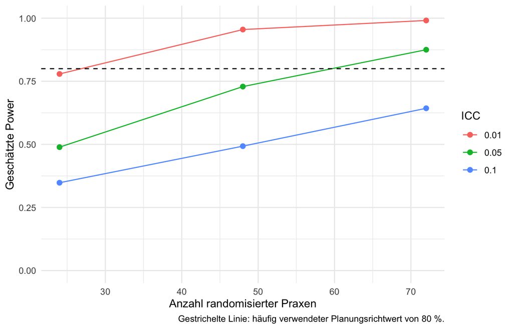

Simulierte Power nach Anzahl Praxen und angenommener ICC (42 Patienten je Praxis)

```r
grafik_daten <- subset(szenarien, patienten_pro_praxis == 42)

ggplot(grafik_daten,
       aes(x = anzahl_praxen, y = power,
           color = factor(icc), group = factor(icc))) +
  geom_line() +
  geom_point(size = 2) +
  geom_hline(yintercept = 0.80, linetype = "dashed") +
  scale_y_continuous(limits = c(0, 1)) +
  labs(
    x = "Anzahl randomisierter Praxen",
    y = "Geschätzte Power",
    color = "ICC",
    caption = "Gestrichelte Linie: häufig verwendeter Planungsrichtwert von 80 %."
  ) +
  theme_minimal()
```

**Erwartung:** Mehr randomisierte Praxen erhöhen tendenziell die Power. Eine höhere ICC reduziert sie meist, weil Patienten derselben Praxis stärkere gemeinsame Schwankungen aufweisen. Durch die begrenzte Zahl der Simulationen können einzelne Linien trotzdem unregelmäßig verlaufen.

## 8.4 Was bringen mehr Patienten pro Praxis?

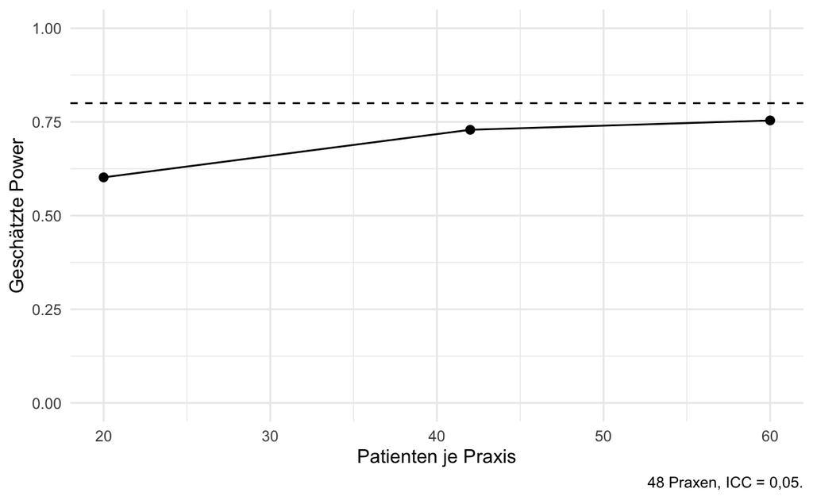

Simulierte Power bei 48 Praxen und ICC = 0,05

```r
groessen_daten <- subset(
  szenarien, anzahl_praxen == 48 & icc == 0.05
)

ggplot(groessen_daten,
       aes(x = patienten_pro_praxis, y = power)) +
  geom_line() +
  geom_point(size = 2) +
  geom_hline(yintercept = 0.80, linetype = "dashed") +
  scale_y_continuous(limits = c(0, 1)) +
  labs(
    x = "Patienten je Praxis",
    y = "Geschätzte Power",
    caption = "48 Praxen, ICC = 0,05."
  ) +
  theme_minimal()
```

**Interpretation:** Mehr Patienten innerhalb derselben Praxis können die Präzision verbessern, ersetzen aber nicht die zusätzliche Information weiterer randomisierter Praxen. Bei positiver ICC nimmt ihr Zusatznutzen typischerweise ab.

# 9 Kontrolle des Signifikanzniveaus unter der Nullhypothese

Eine Power-Simulation sollte nicht nur einen angenommenen Effekt von IRR = 0,80 untersuchen. Wir prüfen auch, wie oft das Verfahren **einen Effekt meldet, obwohl in Wahrheit keiner vorhanden ist**.

Dafür setzen wir `irr = 1`. Der Anteil signifikanter Tests ist dann die **empirische Typ-I-Fehlerrate**. Bei einem nominellen Signifikanzniveau von 5 % sollte sie ungefähr 0,05 betragen. Mit wenigen Clustern können übliche cluster-robuste Verfahren aber ungenau sein.

Die Power gibt an, wie oft unser Test bei einem tatsächlichen Effekt (IRR = 0,80) signifikant wird. Die Typ-I-Fehlerrate zeigt dagegen, wie häufig derselbe Test einen Effekt meldet, obwohl keiner existiert (IRR = 1). Beide Größen müssen gemeinsam beurteilt werden: Ein Test, der generell zu häufig die Nullhypothese verwirft, kann auch eine scheinbar hohe Power erreichen.

```r
#| label: nullsimulation

# Drei Studiendesigns mit unterschiedlicher Praxiszahl
null_ergebnisse <- data.frame(
  anzahl_praxen = c(24, 48, 72),
  typ1_rate = NA_real_
)

for (i in 1:nrow(null_ergebnisse)) {

  # 1. Studien ohne tatsächlichen Interventionseffekt simulieren
  signifikant <- replicate(anzahl_wiederholungen, {

    personen <- simuliere_studie(
      anzahl_praxen = null_ergebnisse$anzahl_praxen[i],
      patienten_pro_praxis = 42,
      icc = 0.05,
      irr = 1.00  # Kein tatsächlicher Interventionseffekt
    )

    # 2. Nur das Signifikanzergebnis auslesen
    ergebnis <- analysiere_studie(personen)
    ergebnis[["signifikant"]]
  })

  # 3. Prüfen, ob alle Simulationen gültig sind
  stopifnot(
    is.numeric(signifikant),
    !anyNA(signifikant),
    all(signifikant %in% c(0, 1))
  )

  # 4. Anteil der fälschlich signifikanten Ergebnisse
  null_ergebnisse$typ1_rate[i] <- mean(signifikant)
}

# Ergebnisse darstellen
kable(
  null_ergebnisse,
  digits = 3,
  col.names = c("Praxen", "Empirische Typ-I-Fehlerrate"),
  caption = "Wie häufig wird unter IRR = 1 ein Effekt gemeldet?"
)
```

Wie häufig wird unter IRR = 1 ein Effekt gemeldet?

| Praxen | Empirische Typ-I-Fehlerrate |
| --- | --- |
| 24 | 0.094 |
| 48 | 0.055 |
| 72 | 0.059 |

**Interpretation:** Wir haben für jedes Studiendesign 1000 Studien ohne tatsächlichen Interventionseffekt (IRR = 1) simuliert. Ein signifikanter Befund ist in diesem Fall ein **Typ-I-Fehler** (falsch-positives Ergebnis).

- **24 Praxen:** 9,4 % (94 von 1000 Studien).
- **48 Praxen:** 5,5 % (55 von 1000 Studien).
- **72 Praxen:** 5,9 % (59 von 1000 Studien).

Bei einem nominellen Signifikanzniveau von 5 % erwarten wir langfristig eine Typ-I-Fehlerrate von ungefähr 5 %.

Die Ergebnisse zeigen, dass die empirische Fehlerrate insbesondere bei 24 Praxen deutlich über diesem Niveau liegt. Bei 48 und 72 Praxen liegt sie dagegen näher am angestrebten Signifikanzniveau.

Dies deutet darauf hin, dass das verwendete Testverfahren bei einer kleineren Anzahl randomisierter Praxen zu häufig falsch-positive Ergebnisse liefern könnte. Allerdings unterliegen auch diese Simulationsergebnisse zufälligen Schwankungen.

# 10 Methodische Grenzen und Interpretation

Dieses Lehrprojekt zeigt die **Grundlogik einer simulationsbasierten Fallzahl- und Powerplanung** für Cluster-RCTs. Es ersetzt keine vollständige Planung einer realen klinischen Studie.

Die wichtigsten Grenzen sind:

- **Vereinfachte Daten:** Jede Praxis hat gleich viele Patienten; alle Personen werden ein Jahr beobachtet. Todesfälle, Drop-out, Nichtnutzung des Angebots und fehlende Werte fehlen.
- **Modellabhängige ICC:** Die vorgegebene ICC ist eine näherungsweise Zielgröße unseres Gamma-Poisson-Modells. Die resultierende Korrelation hängt auch von Ereignisrate und Studienarm ab.
- **Angenommene Effektgröße:** Das IRR von 0,80 ist eine Lehrannahme. Für eine reale Planung müsste es fachlich begründet werden.
- **Keine Kostenoptimierung:** Eine höhere Power bedeutet nicht automatisch, dass ein Studiendesign hinsichtlich Aufwand und Budget optimal ist.
- **Cluster-robuste Inferenz:** Bei wenigen Praxen können p-Werte und Konfidenzintervalle ungenau kalibriert sein. Deshalb beurteilen wir Power und empirische Typ-I-Fehlerrate gemeinsam. Die Nullsimulation ist eine erste Plausibilitätsprüfung, kein allgemeiner Gütenachweis.

**Zentrale Erkenntnis:** In einer Cluster-RCT zählt nicht nur die Anzahl der Patienten. Vor allem die **Anzahl unabhängig randomisierter Praxen** und die **Ähnlichkeit der Patienten innerhalb dieser Praxen** bestimmen, wie präzise wir einen Interventionseffekt untersuchen können.

**Weiterführende Aufgabe:** In einer realistischeren Simulation könntest du ungleiche Praxisgrößen, vorzeitige Todesfälle und unterschiedliche Beobachtungszeiten berücksichtigen. Dann ist für die korrekte Beschreibung der ICC und die Wahl des Zielparameters zusätzliche Sorgfalt nötig.